# Estimating Prediabetes Prevalence in the Faroe Islands

### 4.2 Group-level comparison

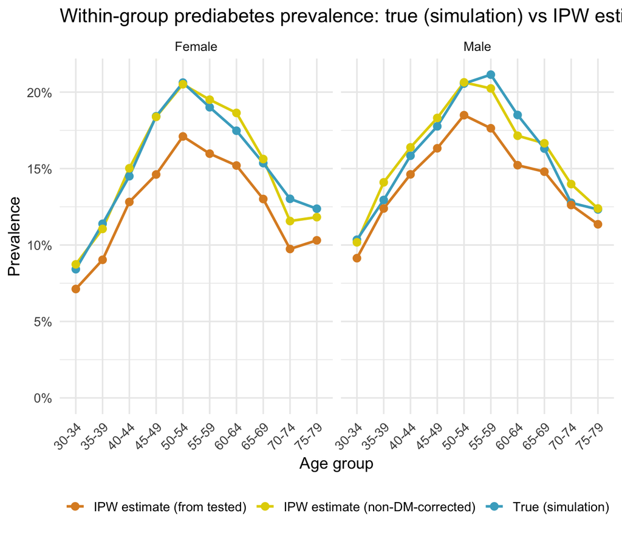

```r
group_comparison <- true_grp |>
  left_join(
    group_stats |> select(age_group, sex, prev_g_marg, prev_g_nondm),
    by = c("age_group", "sex")
  ) |>
  pivot_longer(
    cols      = c(prev_true_g, prev_g_marg, prev_g_nondm),
    names_to  = "type",
    values_to = "prevalence"
  ) |>
  mutate(
    type = case_match(type,
      "prev_true_g" ~ "True (simulation)",
      "prev_g_marg" ~ "IPW estimate (from tested)",
      "prev_g_nondm" ~ "IPW estimate (non-DM-corrected)")
  )
group_comparison |>
  ggplot(aes(x = age_group, y = prevalence, colour = type, group = type)) +
  geom_line(linewidth = 1) +
  geom_point(size = 2.5) +
  facet_wrap(~sex) +
  scale_y_continuous(labels = percent_format(accuracy = 1), limits = c(0, NA)) +
  scale_colour_manual(
      values = wes_palette("FantasticFox1"),
  ) +
  labs(
    title  = "Within-group prediabetes prevalence: true (simulation) vs IPW estimate",
    x      = "Age group", y = "Prevalence", colour = NULL
  ) +
  theme_minimal(base_size = 13) +
  theme(
    axis.text.x     = element_text(angle = 45, hjust = 1),
    legend.position = "bottom"
  )
```

## 5. Methodological Discussion: Are IPW and Standardisation the Same Step?

Your intuition is essentially **correct** in this setting. The two steps are algebraically equivalent, though they are conceptually distinct. Here is a precise account of both.

### 5.1 IPW in this setting

Inverse probability weighting assigns each tested individual a weight $w_i = 1/\hat{p}_g$, where $\hat{p}_g$ is the estimated probability that a person in group $g$ was tested. The IPW overall prevalence estimator is then:

$$\hat{\pi}^{\,\text{IPW}} = \frac{\displaystyle\sum_{\text{tested}} w_i\,\mathbf{1}[\text{pre}_i]}{\displaystyle\sum_{\text{tested}} w_i}$$

Substituting $w_i = N_g / n_g^{\text{tested}}$ (uniform within each group):

$$\hat{\pi}^{\,\text{IPW}} = \frac{\displaystyle\sum_g \frac{N_g}{n_g^{\text{tested}}}\,n_g^{\text{pre}}}{\displaystyle\sum_g \frac{N_g}{n_g^{\text{tested}}}\,n_g^{\text{tested}}} = \frac{\displaystyle\sum_g N_g\,\frac{n_g^{\text{pre}}}{n_g^{\text{tested}}}}{\displaystyle\sum_g N_g} = \sum_g \frac{N_g}{N}\,\hat{\pi}_g$$

This is **exactly the direct standardisation formula**.

### 5.2 What each step actually does

[output not shown]

### 5.3 Why they appear to be a single step

When the probability model is **fully saturated** over discrete strata (each individual’s testing probability is a function of group membership only), the individual-level IPW estimator and the group-level standardised estimator are identical. This is our situation.

The two steps come apart when:

- Testing probability is modelled via a **continuous covariate** (e.g., exact age via logistic regression). Each individual then has a unique weight that does not simply equal $N_g / n_g$.
- The **standardisation target** differs from the source of the IPW weights (e.g., you weight to the Faroese population but standardise to the European Standard Population).
- Testing is not the only source of **selective observation**: for example, if prediabetics are also more likely to present for a follow-up test, the naive within-group proportion would still be biased, and IPW would be doing additional work beyond what standardisation alone achieves.

### 5.4 Take-away

In our scenario your supervisor’s two-step description (*“weight by inverse probability, then standardise”*) collapses to a single computation:

$$\boxed{\hat{\pi}^{\,\text{std}} = \sum_g \frac{N_g}{N} \cdot \frac{n_g^{\text{pre}}}{n_g^{\text{tested}}}}$$